# Starbucks Capstone Challenge

### Introduction

This data set contains simulated data that mimics customer behavior on the Starbucks rewards mobile app. Once every few days, Starbucks sends out an offer to users of the mobile app. An offer can be merely an advertisement for a drink or an actual offer such as a discount or BOGO (buy one get one free). Some users might not receive any offer during certain weeks.

Not all users receive the same offer, and that is the challenge to solve with this data set.

Your task is to combine transaction, demographic and offer data to determine which demographic groups respond best to which offer type. This data set is a simplified version of the real Starbucks app because the underlying simulator only has one product whereas Starbucks actually sells dozens of products.

Every offer has a validity period before the offer expires. As an example, a BOGO offer might be valid for only 5 days. You'll see in the data set that informational offers have a validity period even though these ads are merely providing information about a product; for example, if an informational offer has 7 days of validity, you can assume the customer is feeling the influence of the offer for 7 days after receiving the advertisement.

You'll be given transactional data showing user purchases made on the app including the timestamp of purchase and the amount of money spent on a purchase. This transactional data also has a record for each offer that a user receives as well as a record for when a user actually views the offer. There are also records for when a user completes an offer.

Keep in mind as well that someone using the app might make a purchase through the app without having received an offer or seen an offer.

### Example

To give an example, a user could receive a discount offer buy 10 dollars get 2 off on Monday. The offer is valid for 10 days from receipt. If the customer accumulates at least 10 dollars in purchases during the validity period, the customer completes the offer.

However, there are a few things to watch out for in this data set. Customers do not opt into the offers that they receive; in other words, a user can receive an offer, never actually view the offer, and still complete the offer. For example, a user might receive the "buy 10 dollars get 2 dollars off offer", but the user never opens the offer during the 10 day validity period. The customer spends 15 dollars during those ten days. There will be an offer completion record in the data set; however, the customer was not influenced by the offer because the customer never viewed the offer.

### Cleaning

This makes data cleaning especially important and tricky.

You'll also want to take into account that some demographic groups will make purchases even if they don't receive an offer. From a business perspective, if a customer is going to make a 10 dollar purchase without an offer anyway, you wouldn't want to send a buy 10 dollars get 2 dollars off offer. You'll want to try to assess what a certain demographic group will buy when not receiving any offers.

### Final Advice

Because this is a capstone project, you are free to analyze the data any way you see fit. For example, you could build a machine learning model that predicts how much someone will spend based on demographics and offer type. Or you could build a model that predicts whether or not someone will respond to an offer. Or, you don't need to build a machine learning model at all. You could develop a set of heuristics that determine what offer you should send to each customer (i.e., 75 percent of women customers who were 35 years old responded to offer A vs 40 percent from the same demographic to offer B, so send offer A).

# Data Sets

The data is contained in three files:

- portfolio.json - containing offer ids and meta data about each offer (duration, type, etc.)
- profile.json - demographic data for each customer
- transcript.json - records for transactions, offers received, offers viewed, and offers completed

Here is the schema and explanation of each variable in the files:

**portfolio.json**

- id (string) - offer id
- offer_type (string) - type of offer ie BOGO, discount, informational
- difficulty (int) - minimum required spend to complete an offer
- reward (int) - reward given for completing an offer
- duration (int) - time for offer to be open, in days
- channels (list of strings)

**profile.json**

- age (int) - age of the customer
- became_member_on (int) - date when customer created an app account
- gender (str) - gender of the customer (note some entries contain 'O' for other rather than M or F)
- id (str) - customer id
- income (float) - customer's income

**transcript.json**

- event (str) - record description (ie transaction, offer received, offer viewed, etc.)
- person (str) - customer id
- time (int) - time in hours since start of test. The data begins at time t=0
- value - (dict of strings) - either an offer id or transaction amount depending on the record

## Problem statement

Starbucks needs a way to send to each costumer the right offer.

Our goal is to analyze historical app data to find most appropriate offer for each one of the costumers.

The appropriate offer when the costumer sees the offer and buy the products under the offer influence.

The user can receive an offer, never actually view the offer, and still complete the offer, there will be an offer completion record in the data set, however, the customer was not influenced by the offer because the customer never viewed the offer.

# 1. Load The Data

```python
import pandas as pd
import numpy as np
import math
import datetime as dt
import json
import os
import matplotlib.pyplot as plt
import seaborn as sns
%matplotlib inline

# read in the json files
portfolio = pd.read_json('data/portfolio.json', orient='records', lines=True)
profile = pd.read_json('data/profile.json', orient='records', lines=True)
transcript = pd.read_json('data/transcript.json', orient='records', lines=True)
```

# 2. Data Exploration

```python
print ('portfolio rows: {}, portfolio columns: {}'.format(portfolio.shape[0],portfolio.shape[1]))
portfolio.head(10)
```

```
portfolio rows: 10, portfolio columns: 6
```

|  | reward | channels | difficulty | duration | offer_type | id |
| --- | --- | --- | --- | --- | --- | --- |
| 0 | 10 | [email, mobile, social] | 10 | 7 | bogo | ae264e3637204a6fb9bb56bc8210ddfd |
| 1 | 10 | [web, email, mobile, social] | 10 | 5 | bogo | 4d5c57ea9a6940dd891ad53e9dbe8da0 |
| 2 | 0 | [web, email, mobile] | 0 | 4 | informational | 3f207df678b143eea3cee63160fa8bed |
| 3 | 5 | [web, email, mobile] | 5 | 7 | bogo | 9b98b8c7a33c4b65b9aebfe6a799e6d9 |
| 4 | 5 | [web, email] | 20 | 10 | discount | 0b1e1539f2cc45b7b9fa7c272da2e1d7 |
| 5 | 3 | [web, email, mobile, social] | 7 | 7 | discount | 2298d6c36e964ae4a3e7e9706d1fb8c2 |
| 6 | 2 | [web, email, mobile, social] | 10 | 10 | discount | fafdcd668e3743c1bb461111dcafc2a4 |
| 7 | 0 | [email, mobile, social] | 0 | 3 | informational | 5a8bc65990b245e5a138643cd4eb9837 |
| 8 | 5 | [web, email, mobile, social] | 5 | 5 | bogo | f19421c1d4aa40978ebb69ca19b0e20d |
| 9 | 2 | [web, email, mobile] | 10 | 7 | discount | 2906b810c7d4411798c6938adc9daaa5 |

```python
print ('profile rows: {}, profile columns: {}'.format(profile.shape[0],profile.shape[1]))
profile.sample(10)
```

```
profile rows: 17000, profile columns: 5
```

|  | gender | age | id | became_member_on | income |
| --- | --- | --- | --- | --- | --- |
| 6815 | M | 29 | 365c954d08074683a4bfa8a55f373f86 | 20180529 | 59000.0 |
| 9599 | None | 118 | 6312a8be2d0b41ccb5aafff9eeefd71b | 20160107 | NaN |
| 5979 | M | 56 | d6288202024a428ca83d6729f98b5050 | 20180120 | 73000.0 |
| 15534 | F | 73 | 77e591b6c9244f4e9eee93d69531033f | 20151120 | 60000.0 |
| 7138 | F | 43 | 5334e0dbf1aa4d43a4d07e2a4a5d095f | 20171025 | 64000.0 |
| 9096 | None | 118 | bbac698d05484da5930ea209dda9c087 | 20180418 | NaN |
| 1678 | F | 86 | 19626bf0c0ab416492d1ac3af4d7e06a | 20160715 | 40000.0 |
| 7120 | M | 54 | df9fc9a86ca84ef5aedde8925d5838ba | 20170905 | 65000.0 |
| 5659 | F | 58 | 62d5b9f500494d5293e71f2be052962b | 20161016 | 92000.0 |
| 4170 | M | 54 | b3d1075ec03c4c188bff29c9f4382898 | 20170607 | 71000.0 |

```python
print ('transcript rows: {}, transcript columns: {}'.format(transcript.shape[0],transcript.shape[1]))
transcript.sample(10)
```

```
transcript rows: 306534, transcript columns: 4
```

|  | person | event | value | time |
| --- | --- | --- | --- | --- |
| 90199 | 0200f61c69da4c2ea078842cdaf234e6 | offer completed | {'offer_id': '2298d6c36e964ae4a3e7e9706d1fb8c2... | 228 |
| 304169 | 17b2a48d368b417c8acabacac1f98440 | transaction | {'amount': 29.5} | 702 |
| 116660 | 472179be632343d4a1bcdc081d3a1427 | offer received | {'offer id': '9b98b8c7a33c4b65b9aebfe6a799e6d9'} | 336 |
| 21326 | 9c6b3b60a0fc44c29a39d90c6228b2b3 | transaction | {'amount': 12.39} | 18 |
| 15495 | d41b6155ab804b47a6b6979a06e49d8c | offer viewed | {'offer id': '9b98b8c7a33c4b65b9aebfe6a799e6d9'} | 0 |
| 222195 | 80242cc3d985484fbeeeb7d3cf828b71 | offer completed | {'offer_id': '2298d6c36e964ae4a3e7e9706d1fb8c2... | 516 |
| 39716 | 0f6496ef526940d3a2e091ed2a3056d7 | transaction | {'amount': 25.81} | 90 |
| 33129 | b8cdaf04fcf34321b1e10736f616541d | offer completed | {'offer_id': '9b98b8c7a33c4b65b9aebfe6a799e6d9... | 60 |
| 302548 | d8192bb8400249d18947acf38b2619fa | transaction | {'amount': 8.12} | 696 |
| 290311 | 03637e48ffda4bf9b73b079d03c0bbe3 | transaction | {'amount': 10.58} | 648 |

## Clean profile data

```python
profile
```

|  | gender | age | id | became_member_on | income |
| --- | --- | --- | --- | --- | --- |
| 0 | None | 118 | 68be06ca386d4c31939f3a4f0e3dd783 | 20170212 | NaN |
| 1 | F | 55 | 0610b486422d4921ae7d2bf64640c50b | 20170715 | 112000.0 |
| 2 | None | 118 | 38fe809add3b4fcf9315a9694bb96ff5 | 20180712 | NaN |
| 3 | F | 75 | 78afa995795e4d85b5d9ceeca43f5fef | 20170509 | 100000.0 |
| 4 | None | 118 | a03223e636434f42ac4c3df47e8bac43 | 20170804 | NaN |
| ... | ... | ... | ... | ... | ... |
| 16995 | F | 45 | 6d5f3a774f3d4714ab0c092238f3a1d7 | 20180604 | 54000.0 |
| 16996 | M | 61 | 2cb4f97358b841b9a9773a7aa05a9d77 | 20180713 | 72000.0 |
| 16997 | M | 49 | 01d26f638c274aa0b965d24cefe3183f | 20170126 | 73000.0 |
| 16998 | F | 83 | 9dc1421481194dcd9400aec7c9ae6366 | 20160307 | 50000.0 |
| 16999 | F | 62 | e4052622e5ba45a8b96b59aba68cf068 | 20170722 | 82000.0 |

17000 rows × 5 columns

```python
profile.isna().sum()
```

```
gender              2175
age                    0
id                     0
became_member_on       0
income              2175
dtype: int64
```

```python
#drop any incomplete rows
profile.dropna(inplace = True)
profile.shape
```

```
(14825, 5)
```

```python
#Change column id in profile data to customer_id
profile.rename(columns = {'id': 'customer_id'}, inplace=True)
```

```python
#change became_member_on to date format
profile.became_member_on = pd.to_datetime(profile.became_member_on,format='%Y%m%d')
```

```python
#make column 'start_year' in profile
profile['start_year'] = profile['became_member_on'].dt.year
```

```python
#make column 'start_month' in profile
profile['start_month'] = profile['became_member_on'].dt.month
```

```python
#gender
profile['gender'].value_counts()
```

```
M    8484
F    6129
O     212
Name: gender, dtype: int64
```

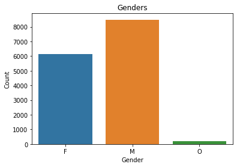

```python
sns.countplot(profile['gender'])
plt.title('Genders')
plt.ylabel('Count')
plt.xlabel('Gender')
plt.show()
```

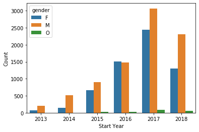

```python
#plot grouping of start_year and gender
gender_year = profile.groupby(['start_year', 'gender']).size()
gender_year = gender_year.reset_index()
gender_year.columns = ['start_year', 'gender', 'count']
sns.barplot(x = 'start_year', y = 'count', hue = 'gender', data = gender_year)
plt.xlabel('Start Year')
plt.ylabel('Count')
plt.show()
```

```python
#making column for every category in gender then drop the gender column
profile['male'] = profile['gender'].apply(lambda x: 1 if x == 'M' else 0)

profile['female'] = profile['gender'].apply(lambda x: 1 if x == 'F' else 0)

profile['other'] = profile['gender'].apply(lambda x: 1 if x == 'O' else 0)

#profile.drop(columns = ['gender'], inplace = True)
```

```python
#print to see the result
print(profile['male'].value_counts())

print(profile['female'].value_counts())

print(profile['other'].value_counts())
```

```
1    8484
0    6341
Name: male, dtype: int64
0    8696
1    6129
Name: female, dtype: int64
0    14613
1      212
Name: other, dtype: int64
```

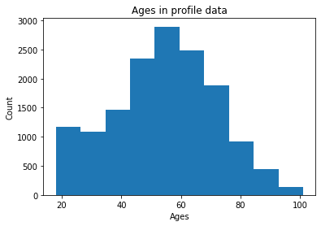

```python
#plot for age distribution
plt.hist(profile['age'])
plt.xlabel('Ages')
plt.ylabel('Count')
plt.title('Ages in profile data')
plt.show()
```

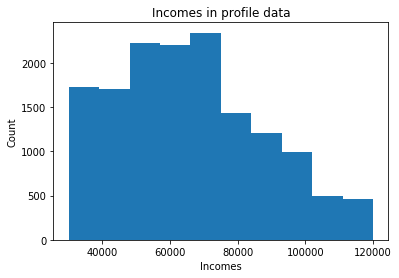

```python
#plot income distribution
plt.hist(profile['income'])
plt.xlabel('Incomes')
plt.ylabel('Count')
plt.title('Incomes in profile data')
plt.show()
```

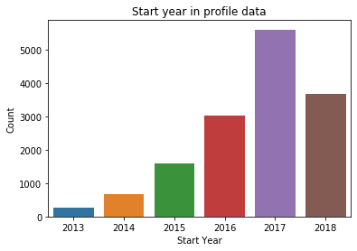

```python
#plot srart year distribution
#plt.hist(profile['start_year'])
sns.countplot(profile['start_year'])
plt.xlabel('Start Year')
plt.ylabel('Count')
plt.title('Start year in profile data')
plt.show()
```

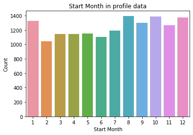

```python
#plot a histogram for start month distribution
#plt.hist(profile['start_month'])
sns.countplot(profile['start_month'])
plt.xlabel('Start Month')
plt.ylabel('Count')
plt.title('Start Month in profile data')
plt.show()
```

```python
profile
```

|  | gender | age | customer_id | became_member_on | income | start_year | start_month | male | female | other |
| --- | --- | --- | --- | --- | --- | --- | --- | --- | --- | --- |
| 1 | F | 55 | 0610b486422d4921ae7d2bf64640c50b | 2017-07-15 | 112000.0 | 2017 | 7 | 0 | 1 | 0 |
| 3 | F | 75 | 78afa995795e4d85b5d9ceeca43f5fef | 2017-05-09 | 100000.0 | 2017 | 5 | 0 | 1 | 0 |
| 5 | M | 68 | e2127556f4f64592b11af22de27a7932 | 2018-04-26 | 70000.0 | 2018 | 4 | 1 | 0 | 0 |
| 8 | M | 65 | 389bc3fa690240e798340f5a15918d5c | 2018-02-09 | 53000.0 | 2018 | 2 | 1 | 0 | 0 |
| 12 | M | 58 | 2eeac8d8feae4a8cad5a6af0499a211d | 2017-11-11 | 51000.0 | 2017 | 11 | 1 | 0 | 0 |
| ... | ... | ... | ... | ... | ... | ... | ... | ... | ... | ... |
| 16995 | F | 45 | 6d5f3a774f3d4714ab0c092238f3a1d7 | 2018-06-04 | 54000.0 | 2018 | 6 | 0 | 1 | 0 |
| 16996 | M | 61 | 2cb4f97358b841b9a9773a7aa05a9d77 | 2018-07-13 | 72000.0 | 2018 | 7 | 1 | 0 | 0 |
| 16997 | M | 49 | 01d26f638c274aa0b965d24cefe3183f | 2017-01-26 | 73000.0 | 2017 | 1 | 1 | 0 | 0 |
| 16998 | F | 83 | 9dc1421481194dcd9400aec7c9ae6366 | 2016-03-07 | 50000.0 | 2016 | 3 | 0 | 1 | 0 |
| 16999 | F | 62 | e4052622e5ba45a8b96b59aba68cf068 | 2017-07-22 | 82000.0 | 2017 | 7 | 0 | 1 | 0 |

14825 rows × 10 columns

## Clean portfolio

```python
portfolio
```

|  | reward | channels | difficulty | duration | offer_type | id |
| --- | --- | --- | --- | --- | --- | --- |
| 0 | 10 | [email, mobile, social] | 10 | 7 | bogo | ae264e3637204a6fb9bb56bc8210ddfd |
| 1 | 10 | [web, email, mobile, social] | 10 | 5 | bogo | 4d5c57ea9a6940dd891ad53e9dbe8da0 |
| 2 | 0 | [web, email, mobile] | 0 | 4 | informational | 3f207df678b143eea3cee63160fa8bed |
| 3 | 5 | [web, email, mobile] | 5 | 7 | bogo | 9b98b8c7a33c4b65b9aebfe6a799e6d9 |
| 4 | 5 | [web, email] | 20 | 10 | discount | 0b1e1539f2cc45b7b9fa7c272da2e1d7 |
| 5 | 3 | [web, email, mobile, social] | 7 | 7 | discount | 2298d6c36e964ae4a3e7e9706d1fb8c2 |
| 6 | 2 | [web, email, mobile, social] | 10 | 10 | discount | fafdcd668e3743c1bb461111dcafc2a4 |
| 7 | 0 | [email, mobile, social] | 0 | 3 | informational | 5a8bc65990b245e5a138643cd4eb9837 |
| 8 | 5 | [web, email, mobile, social] | 5 | 5 | bogo | f19421c1d4aa40978ebb69ca19b0e20d |
| 9 | 2 | [web, email, mobile] | 10 | 7 | discount | 2906b810c7d4411798c6938adc9daaa5 |

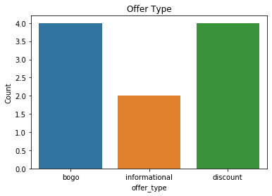

```python
sns.countplot(portfolio['offer_type'])
plt.title('Offer Type')
plt.ylabel('Count')
plt.xlabel('offer_type')
plt.show()
```

```python
#rename column id to offer_id
portfolio.rename(columns = {'id': 'offer_id'}, inplace=True)


#make column for each channel in the data then drop the channels column
portfolio['web'] = portfolio['channels'].apply(lambda x: 1 if 'web' in x else 0)

portfolio['email'] = portfolio['channels'].apply(lambda x: 1 if 'email' in x else 0)

portfolio['mobile'] = portfolio['channels'].apply(lambda x: 1 if 'mobile' in x else 0)

portfolio['social'] = portfolio['channels'].apply(lambda x: 1 if 'social' in x else 0)

portfolio.drop(columns = ['channels'], inplace = True)
```

```python
#make column for each offer type then drop the offer_type column
portfolio['bogo'] = portfolio['offer_type'].apply(lambda x: 1 if 'bogo' in x else 0)

portfolio['discount'] = portfolio['offer_type'].apply(lambda x: 1 if 'discount' in x else 0)

portfolio['informational'] = portfolio['offer_type'].apply(lambda x: 1 if 'informational' in x else 0)

#portfolio.drop(columns = ['offer_type'], inplace = True)
```

```python
portfolio
```

|  | reward | difficulty | duration | offer_type | offer_id | web | email | mobile | social | bogo | discount | informational |
| --- | --- | --- | --- | --- | --- | --- | --- | --- | --- | --- | --- | --- |
| 0 | 10 | 10 | 7 | bogo | ae264e3637204a6fb9bb56bc8210ddfd | 0 | 1 | 1 | 1 | 1 | 0 | 0 |
| 1 | 10 | 10 | 5 | bogo | 4d5c57ea9a6940dd891ad53e9dbe8da0 | 1 | 1 | 1 | 1 | 1 | 0 | 0 |
| 2 | 0 | 0 | 4 | informational | 3f207df678b143eea3cee63160fa8bed | 1 | 1 | 1 | 0 | 0 | 0 | 1 |
| 3 | 5 | 5 | 7 | bogo | 9b98b8c7a33c4b65b9aebfe6a799e6d9 | 1 | 1 | 1 | 0 | 1 | 0 | 0 |
| 4 | 5 | 20 | 10 | discount | 0b1e1539f2cc45b7b9fa7c272da2e1d7 | 1 | 1 | 0 | 0 | 0 | 1 | 0 |
| 5 | 3 | 7 | 7 | discount | 2298d6c36e964ae4a3e7e9706d1fb8c2 | 1 | 1 | 1 | 1 | 0 | 1 | 0 |
| 6 | 2 | 10 | 10 | discount | fafdcd668e3743c1bb461111dcafc2a4 | 1 | 1 | 1 | 1 | 0 | 1 | 0 |
| 7 | 0 | 0 | 3 | informational | 5a8bc65990b245e5a138643cd4eb9837 | 0 | 1 | 1 | 1 | 0 | 0 | 1 |
| 8 | 5 | 5 | 5 | bogo | f19421c1d4aa40978ebb69ca19b0e20d | 1 | 1 | 1 | 1 | 1 | 0 | 0 |
| 9 | 2 | 10 | 7 | discount | 2906b810c7d4411798c6938adc9daaa5 | 1 | 1 | 1 | 0 | 0 | 1 | 0 |

## Clean transcript data

```python
transcript
```

|  | person | event | value | time |
| --- | --- | --- | --- | --- |
| 0 | 78afa995795e4d85b5d9ceeca43f5fef | offer received | {'offer id': '9b98b8c7a33c4b65b9aebfe6a799e6d9'} | 0 |
| 1 | a03223e636434f42ac4c3df47e8bac43 | offer received | {'offer id': '0b1e1539f2cc45b7b9fa7c272da2e1d7'} | 0 |
| 2 | e2127556f4f64592b11af22de27a7932 | offer received | {'offer id': '2906b810c7d4411798c6938adc9daaa5'} | 0 |
| 3 | 8ec6ce2a7e7949b1bf142def7d0e0586 | offer received | {'offer id': 'fafdcd668e3743c1bb461111dcafc2a4'} | 0 |
| 4 | 68617ca6246f4fbc85e91a2a49552598 | offer received | {'offer id': '4d5c57ea9a6940dd891ad53e9dbe8da0'} | 0 |
| ... | ... | ... | ... | ... |
| 306529 | b3a1272bc9904337b331bf348c3e8c17 | transaction | {'amount': 1.5899999999999999} | 714 |
| 306530 | 68213b08d99a4ae1b0dcb72aebd9aa35 | transaction | {'amount': 9.53} | 714 |
| 306531 | a00058cf10334a308c68e7631c529907 | transaction | {'amount': 3.61} | 714 |
| 306532 | 76ddbd6576844afe811f1a3c0fbb5bec | transaction | {'amount': 3.5300000000000002} | 714 |
| 306533 | c02b10e8752c4d8e9b73f918558531f7 | transaction | {'amount': 4.05} | 714 |

306534 rows × 4 columns

```python
#seperate value column to two columns then drop the value column
transcript = transcript[transcript['value'].apply(lambda x: True if ('offer id' in x) or ('offer_id' in x) or ('amount' in x)  else False)]

transcript['offer_id'] = transcript['value'].apply(lambda x: x['offer id'] if ('offer id' in x) else (x['offer_id'] if ('offer_id' in x)  else '0'))

transcript['amount'] = transcript['value'].apply(lambda x: x['amount'] if 'amount' in x else '0')

transcript.drop(columns = ['value'], inplace = True)
```

```python
#rename column person to customer_id
transcript.rename(columns = {'person': 'customer_id'}, inplace=True)
```

```python
#change the type of amount column from object to float
transcript['amount'] = pd.to_numeric(transcript['amount'])
```

```python
#change time from hours to days
transcript['time'] /= 24
```

```python
#drop any data of users not in profile data
transcript = transcript[transcript['customer_id'].isin(profile['customer_id'])]
```

```python
#check if there's any duplicated values
transcript.duplicated().sum()
```

```
374
```

```python
#delete the duplicated values
transcript.drop_duplicates(inplace = True)

#reset indecies of the data
transcript.reset_index(drop = True, inplace = True)
```

```python
transcript
```

|  | customer_id | event | time | offer_id | amount |
| --- | --- | --- | --- | --- | --- |
| 0 | 78afa995795e4d85b5d9ceeca43f5fef | offer received | 0.00 | 9b98b8c7a33c4b65b9aebfe6a799e6d9 | 0.00 |
| 1 | e2127556f4f64592b11af22de27a7932 | offer received | 0.00 | 2906b810c7d4411798c6938adc9daaa5 | 0.00 |
| 2 | 389bc3fa690240e798340f5a15918d5c | offer received | 0.00 | f19421c1d4aa40978ebb69ca19b0e20d | 0.00 |
| 3 | 2eeac8d8feae4a8cad5a6af0499a211d | offer received | 0.00 | 3f207df678b143eea3cee63160fa8bed | 0.00 |
| 4 | aa4862eba776480b8bb9c68455b8c2e1 | offer received | 0.00 | 0b1e1539f2cc45b7b9fa7c272da2e1d7 | 0.00 |
| ... | ... | ... | ... | ... | ... |
| 272383 | 24f56b5e1849462093931b164eb803b5 | offer completed | 29.75 | fafdcd668e3743c1bb461111dcafc2a4 | 0.00 |
| 272384 | b3a1272bc9904337b331bf348c3e8c17 | transaction | 29.75 | 0 | 1.59 |
| 272385 | 68213b08d99a4ae1b0dcb72aebd9aa35 | transaction | 29.75 | 0 | 9.53 |
| 272386 | a00058cf10334a308c68e7631c529907 | transaction | 29.75 | 0 | 3.61 |
| 272387 | 76ddbd6576844afe811f1a3c0fbb5bec | transaction | 29.75 | 0 | 3.53 |

272388 rows × 5 columns

### There's two categories in the transcript data, transaction and offers (offer received, offer viewed, offer completed)

#### so the we'll split the data anto transaction and offers

```python
#split the data frame into two data frames

#the transactions
transaction = transcript[transcript['event'] == 'transaction'].copy()


#drop columns 'offer_id' and 'event'

transaction.drop(columns = ['offer_id', 'event'], inplace = True)
```

```python
transaction.shape
```

```
(123957, 3)
```

```python
#the offers
offers = transcript[transcript['event'] != 'transaction'].copy()
```

```python
offers.shape
```

```
(148431, 5)
```

```python
#make column for each event type
offers['offer_received'] = offers['event'].apply(lambda x: 1 if x == 'offer received' else 0)

offers['offer_viewed'] = offers['event'].apply(lambda x: 1 if x == 'offer viewed' else 0)

offers['offer_completed'] = offers['event'].apply(lambda x: 1 if x == 'offer completed' else 0)
```

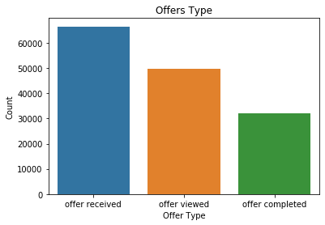

```python
#plot the count of each offer type
sns.countplot(offers['event'])
plt.title('Offers Type')
plt.ylabel('Count')
plt.xlabel('Offer Type')
plt.show()
```

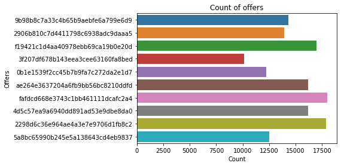

```python
#plot count of offers
sns.countplot(y = offers['offer_id'])
plt.title('Count of offers')
plt.ylabel('Offers')
plt.xlabel('Count')
plt.show()
```

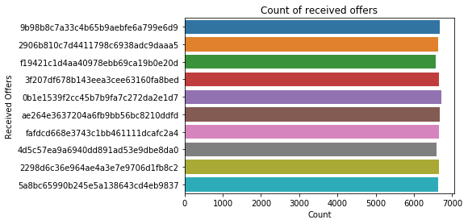

```python
#plot count of the recevied offers
sns.countplot(y = offers[offers['event'] == 'offer received']['offer_id'])
plt.title('Count of received offers')
plt.ylabel('Received Offers')
plt.xlabel('Count')
plt.show()
```

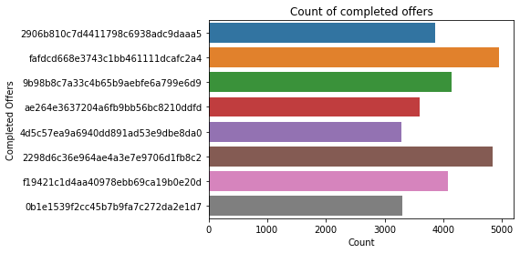

```python
#plot count of the completed offers
sns.countplot(y = offers[offers['event'] == 'offer completed']['offer_id'])
plt.title('Count of completed offers')
plt.ylabel('Completed Offers')
plt.xlabel('Count')
plt.show()
```

```python
offers
```

|  | customer_id | event | time | offer_id | amount | offer_received | offer_viewed | offer_completed |
| --- | --- | --- | --- | --- | --- | --- | --- | --- |
| 0 | 78afa995795e4d85b5d9ceeca43f5fef | offer received | 0.00 | 9b98b8c7a33c4b65b9aebfe6a799e6d9 | 0.0 | 1 | 0 | 0 |
| 1 | e2127556f4f64592b11af22de27a7932 | offer received | 0.00 | 2906b810c7d4411798c6938adc9daaa5 | 0.0 | 1 | 0 | 0 |
| 2 | 389bc3fa690240e798340f5a15918d5c | offer received | 0.00 | f19421c1d4aa40978ebb69ca19b0e20d | 0.0 | 1 | 0 | 0 |
| 3 | 2eeac8d8feae4a8cad5a6af0499a211d | offer received | 0.00 | 3f207df678b143eea3cee63160fa8bed | 0.0 | 1 | 0 | 0 |
| 4 | aa4862eba776480b8bb9c68455b8c2e1 | offer received | 0.00 | 0b1e1539f2cc45b7b9fa7c272da2e1d7 | 0.0 | 1 | 0 | 0 |
| ... | ... | ... | ... | ... | ... | ... | ... | ... |
| 272343 | 84fb57a7fe8045a8bf6236738ee73a0f | offer viewed | 29.75 | 5a8bc65990b245e5a138643cd4eb9837 | 0.0 | 0 | 1 | 0 |
| 272350 | abc4359eb34e4e2ca2349da2ddf771b6 | offer viewed | 29.75 | 3f207df678b143eea3cee63160fa8bed | 0.0 | 0 | 1 | 0 |
| 272363 | 8dda575c2a1d44b9ac8e8b07b93d1f8e | offer viewed | 29.75 | 0b1e1539f2cc45b7b9fa7c272da2e1d7 | 0.0 | 0 | 1 | 0 |
| 272365 | 8431c16f8e1d440880db371a68f82dd0 | offer completed | 29.75 | fafdcd668e3743c1bb461111dcafc2a4 | 0.0 | 0 | 0 | 1 |
| 272383 | 24f56b5e1849462093931b164eb803b5 | offer completed | 29.75 | fafdcd668e3743c1bb461111dcafc2a4 | 0.0 | 0 | 0 | 1 |

148431 rows × 8 columns

```python
profile
```

|  | gender | age | customer_id | became_member_on | income | start_year | start_month | male | female | other |
| --- | --- | --- | --- | --- | --- | --- | --- | --- | --- | --- |
| 1 | F | 55 | 0610b486422d4921ae7d2bf64640c50b | 2017-07-15 | 112000.0 | 2017 | 7 | 0 | 1 | 0 |
| 3 | F | 75 | 78afa995795e4d85b5d9ceeca43f5fef | 2017-05-09 | 100000.0 | 2017 | 5 | 0 | 1 | 0 |
| 5 | M | 68 | e2127556f4f64592b11af22de27a7932 | 2018-04-26 | 70000.0 | 2018 | 4 | 1 | 0 | 0 |
| 8 | M | 65 | 389bc3fa690240e798340f5a15918d5c | 2018-02-09 | 53000.0 | 2018 | 2 | 1 | 0 | 0 |
| 12 | M | 58 | 2eeac8d8feae4a8cad5a6af0499a211d | 2017-11-11 | 51000.0 | 2017 | 11 | 1 | 0 | 0 |
| ... | ... | ... | ... | ... | ... | ... | ... | ... | ... | ... |
| 16995 | F | 45 | 6d5f3a774f3d4714ab0c092238f3a1d7 | 2018-06-04 | 54000.0 | 2018 | 6 | 0 | 1 | 0 |
| 16996 | M | 61 | 2cb4f97358b841b9a9773a7aa05a9d77 | 2018-07-13 | 72000.0 | 2018 | 7 | 1 | 0 | 0 |
| 16997 | M | 49 | 01d26f638c274aa0b965d24cefe3183f | 2017-01-26 | 73000.0 | 2017 | 1 | 1 | 0 | 0 |
| 16998 | F | 83 | 9dc1421481194dcd9400aec7c9ae6366 | 2016-03-07 | 50000.0 | 2016 | 3 | 0 | 1 | 0 |
| 16999 | F | 62 | e4052622e5ba45a8b96b59aba68cf068 | 2017-07-22 | 82000.0 | 2017 | 7 | 0 | 1 | 0 |

14825 rows × 10 columns

```python
transaction
```

|  | customer_id | time | amount |
| --- | --- | --- | --- |
| 11027 | 02c083884c7d45b39cc68e1314fec56c | 0.00 | 0.83 |
| 11030 | 9fa9ae8f57894cc9a3b8a9bbe0fc1b2f | 0.00 | 34.56 |
| 11032 | 54890f68699049c2a04d415abc25e717 | 0.00 | 13.23 |
| 11040 | b2f1cd155b864803ad8334cdf13c4bd2 | 0.00 | 19.51 |
| 11041 | fe97aa22dd3e48c8b143116a8403dd52 | 0.00 | 18.97 |
| ... | ... | ... | ... |
| 272382 | 24f56b5e1849462093931b164eb803b5 | 29.75 | 22.64 |
| 272384 | b3a1272bc9904337b331bf348c3e8c17 | 29.75 | 1.59 |
| 272385 | 68213b08d99a4ae1b0dcb72aebd9aa35 | 29.75 | 9.53 |
| 272386 | a00058cf10334a308c68e7631c529907 | 29.75 | 3.61 |
| 272387 | 76ddbd6576844afe811f1a3c0fbb5bec | 29.75 | 3.53 |

123957 rows × 3 columns

```python
portfolio
```

|  | reward | difficulty | duration | offer_type | offer_id | web | email | mobile | social | bogo | discount | informational |
| --- | --- | --- | --- | --- | --- | --- | --- | --- | --- | --- | --- | --- |
| 0 | 10 | 10 | 7 | bogo | ae264e3637204a6fb9bb56bc8210ddfd | 0 | 1 | 1 | 1 | 1 | 0 | 0 |
| 1 | 10 | 10 | 5 | bogo | 4d5c57ea9a6940dd891ad53e9dbe8da0 | 1 | 1 | 1 | 1 | 1 | 0 | 0 |
| 2 | 0 | 0 | 4 | informational | 3f207df678b143eea3cee63160fa8bed | 1 | 1 | 1 | 0 | 0 | 0 | 1 |
| 3 | 5 | 5 | 7 | bogo | 9b98b8c7a33c4b65b9aebfe6a799e6d9 | 1 | 1 | 1 | 0 | 1 | 0 | 0 |
| 4 | 5 | 20 | 10 | discount | 0b1e1539f2cc45b7b9fa7c272da2e1d7 | 1 | 1 | 0 | 0 | 0 | 1 | 0 |
| 5 | 3 | 7 | 7 | discount | 2298d6c36e964ae4a3e7e9706d1fb8c2 | 1 | 1 | 1 | 1 | 0 | 1 | 0 |
| 6 | 2 | 10 | 10 | discount | fafdcd668e3743c1bb461111dcafc2a4 | 1 | 1 | 1 | 1 | 0 | 1 | 0 |
| 7 | 0 | 0 | 3 | informational | 5a8bc65990b245e5a138643cd4eb9837 | 0 | 1 | 1 | 1 | 0 | 0 | 1 |
| 8 | 5 | 5 | 5 | bogo | f19421c1d4aa40978ebb69ca19b0e20d | 1 | 1 | 1 | 1 | 1 | 0 | 0 |
| 9 | 2 | 10 | 7 | discount | 2906b810c7d4411798c6938adc9daaa5 | 1 | 1 | 1 | 0 | 0 | 1 | 0 |

## After Cleaning all the data we need to combine the all of this to make one dataset for modeling.

#### This is the most important part of the project, Good feature engineering means good model.

```python
def combine_data(profile, offers, transaction, portfolio):
    """
    function to combine all the data to single dataset for modeling
    INPUT:
        profile: dataframe contains all profiles of the customers
        offers: dataframe contains all the offers that made
        transactions: dataframe contains all the transactions that made
        portfolio: dataframe contains the cuurent offers

    OUTPUT:
        combined_data: dataframe contains combined data that will be used for modeling
    """


    combined_data = []

    #get the customers in offers
    customers = offers['customer_id'].unique()

    #loop through all customers
    for customer_id in customers:
        #get the customer info from profile data
        customer = profile[profile['customer_id'] == customer_id]

        #get all the offers and transactions that belonges to that customer
        customer_offers = offers[offers['customer_id'] == customer_id]
        customer_transactions = transaction[transaction['customer_id'] == customer_id]

        #seperate the customer_offers to each category
        offer_received = customer_offers[customer_offers['offer_received'] == 1]
        offer_viewed = customer_offers[customer_offers['offer_viewed'] == 1]
        offer_completed = customer_offers[customer_offers['offer_completed'] == 1]

        #loop through all the offers for the customer
        records = []
        for j in range (offer_received.shape[0]):
            #get the offer id and offer info from portfolio data
            offer_id = offer_received.iloc[j]['offer_id']
            offer = portfolio.loc[portfolio['offer_id'] == offer_id]

            #get the duration of the offer
            duration = offer['duration'].values[0]

            #calculate start and end time
            start = offer_received.iloc[j]['time']
            end = start + duration

            #see if the customer viewd and completed the offer in time
            is_viewed = np.logical_and(offer_viewed['time'] >= start, offer_viewed['time'] <= end)
            is_completed = np.logical_and(offer_completed['time'] >= start, offer_completed['time'] <= end)

            #mark the offer as successful or not, this is our output class
            success = is_viewed.sum() > 0 and is_completed.sum() > 0

            #calculate the amount of money spent by customer
            transactions_in_time = np.logical_and(customer_transactions['time'] >= start, customer_transactions['time'] <= end)
            transactions = customer_transactions[transactions_in_time]
            spent = transactions['amount'].sum()

            #make dictionary of the data
            record = {
                'success': int(success),
                'offer_id': offer_id,
                'customer_id': customer_id,
                'time': start,
                'spent': spent,
            }

            #complete the row with rest of customer data and offer data
            record.update(offer.iloc[0,0:].to_dict())
            record.update(customer.iloc[0,:].to_dict())
            records.append(record)
        #add this data to our combined data
        combined_data.extend(records)

    #make the dataframe
    combined_data = pd.DataFrame(combined_data)

    return combined_data
```

```python
%%time
combined_data = combine_data(profile, offers, transaction, portfolio)
combined_data
```

```
Wall time: 10min 3s
```

|  | success | offer_id | customer_id | time | spent | reward | difficulty | duration | offer_type | web | ... | informational | gender | age | became_member_on | income | start_year | start_month | male | female | other |
| --- | --- | --- | --- | --- | --- | --- | --- | --- | --- | --- | --- | --- | --- | --- | --- | --- | --- | --- | --- | --- | --- |
| 0 | 1 | 9b98b8c7a33c4b65b9aebfe6a799e6d9 | 78afa995795e4d85b5d9ceeca43f5fef | 0.0 | 37.67 | 5 | 5 | 7 | bogo | 1 | ... | 0 | F | 75 | 2017-05-09 | 100000.0 | 2017 | 5 | 0 | 1 | 0 |
| 1 | 0 | 5a8bc65990b245e5a138643cd4eb9837 | 78afa995795e4d85b5d9ceeca43f5fef | 7.0 | 49.39 | 0 | 0 | 3 | informational | 0 | ... | 1 | F | 75 | 2017-05-09 | 100000.0 | 2017 | 5 | 0 | 1 | 0 |
| 2 | 1 | ae264e3637204a6fb9bb56bc8210ddfd | 78afa995795e4d85b5d9ceeca43f5fef | 17.0 | 48.28 | 10 | 10 | 7 | bogo | 0 | ... | 0 | F | 75 | 2017-05-09 | 100000.0 | 2017 | 5 | 0 | 1 | 0 |
| 3 | 1 | f19421c1d4aa40978ebb69ca19b0e20d | 78afa995795e4d85b5d9ceeca43f5fef | 21.0 | 48.28 | 5 | 5 | 5 | bogo | 1 | ... | 0 | F | 75 | 2017-05-09 | 100000.0 | 2017 | 5 | 0 | 1 | 0 |
| 4 | 0 | 2906b810c7d4411798c6938adc9daaa5 | e2127556f4f64592b11af22de27a7932 | 0.0 | 0.00 | 2 | 10 | 7 | discount | 1 | ... | 0 | M | 68 | 2018-04-26 | 70000.0 | 2018 | 4 | 1 | 0 | 0 |
| ... | ... | ... | ... | ... | ... | ... | ... | ... | ... | ... | ... | ... | ... | ... | ... | ... | ... | ... | ... | ... | ... |
| 66496 | 0 | 2906b810c7d4411798c6938adc9daaa5 | 3cc622f76e464bc1809a71e871579d6c | 24.0 | 34.04 | 2 | 10 | 7 | discount | 1 | ... | 0 | M | 59 | 2017-08-20 | 44000.0 | 2017 | 8 | 1 | 0 | 0 |
| 66497 | 0 | 5a8bc65990b245e5a138643cd4eb9837 | 01fe5ec668f241608eb2f7ec374cb1b7 | 24.0 | 19.92 | 0 | 0 | 3 | informational | 0 | ... | 1 | M | 44 | 2017-08-02 | 64000.0 | 2017 | 8 | 1 | 0 | 0 |
| 66498 | 0 | 9b98b8c7a33c4b65b9aebfe6a799e6d9 | d825b707198046e39baa4fdcfa11d621 | 24.0 | 28.42 | 5 | 5 | 7 | bogo | 1 | ... | 0 | M | 61 | 2018-04-23 | 73000.0 | 2018 | 4 | 1 | 0 | 0 |
| 66499 | 1 | 2298d6c36e964ae4a3e7e9706d1fb8c2 | c207a8a8ef5c47ee970ca45f859e07eb | 24.0 | 75.84 | 3 | 7 | 7 | discount | 1 | ... | 0 | F | 52 | 2017-12-23 | 86000.0 | 2017 | 12 | 0 | 1 | 0 |
| 66500 | 1 | 2298d6c36e964ae4a3e7e9706d1fb8c2 | 9a3f45cf29ef428b932492c7a5d6ac52 | 24.0 | 14.25 | 3 | 7 | 7 | discount | 1 | ... | 0 | M | 20 | 2016-10-19 | 70000.0 | 2016 | 10 | 1 | 0 | 0 |

66501 rows × 25 columns

```python
combined_data.info()
```

```
<class 'pandas.core.frame.DataFrame'>
RangeIndex: 66501 entries, 0 to 66500
Data columns (total 25 columns):
 #   Column            Non-Null Count  Dtype
---  ------            --------------  -----
 0   success           66501 non-null  int64
 1   offer_id          66501 non-null  object
 2   customer_id       66501 non-null  object
 3   time              66501 non-null  float64
 4   spent             66501 non-null  float64
 5   reward            66501 non-null  int64
 6   difficulty        66501 non-null  int64
 7   duration          66501 non-null  int64
 8   offer_type        66501 non-null  object
 9   web               66501 non-null  int64
```

[output cut: 17 more lines]

```python
#successful offers
successful = combined_data[combined_data['success'] == 1]
```

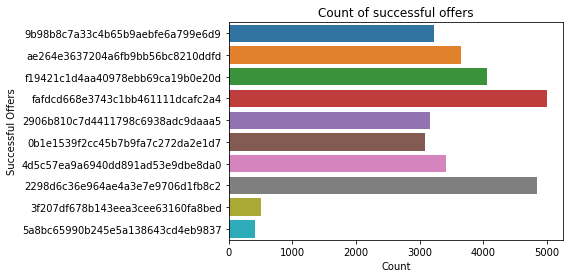

```python
#plot count of successful offers
sns.countplot(y = successful['offer_id'])
plt.title('Count of successful offers')
plt.ylabel('Successful Offers')
plt.xlabel('Count')
plt.show()
```

```python
sns.set(rc={'figure.figsize':(11.7,8.27)})
```

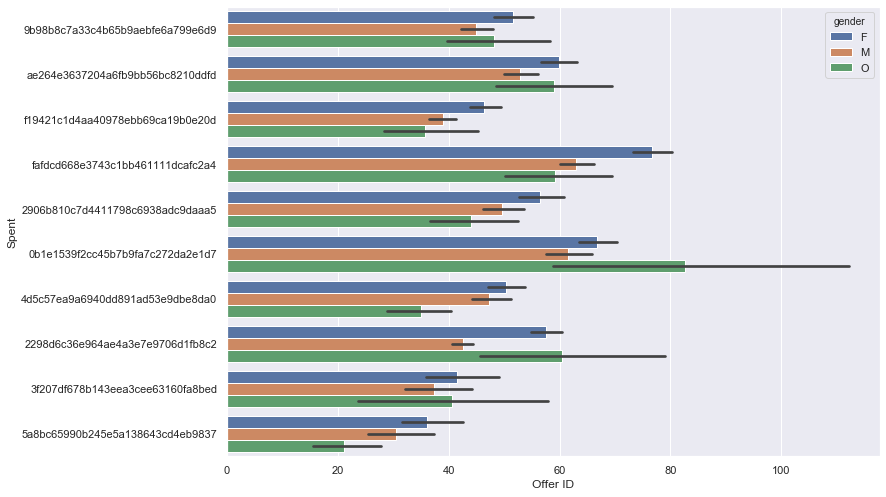

```python
sns.barplot(x = 'spent', y = 'offer_id', hue = 'gender', data = successful)
plt.xlabel('Offer ID')
plt.ylabel('Spent')
plt.show()
```

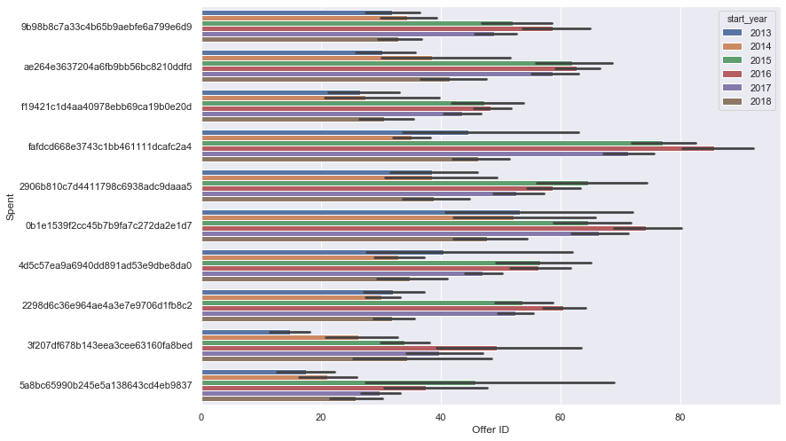

```python
sns.barplot(x = 'spent', y = 'offer_id', hue = 'start_year', data = successful)
plt.xlabel('Offer ID')
plt.ylabel('Spent')
plt.show()
```

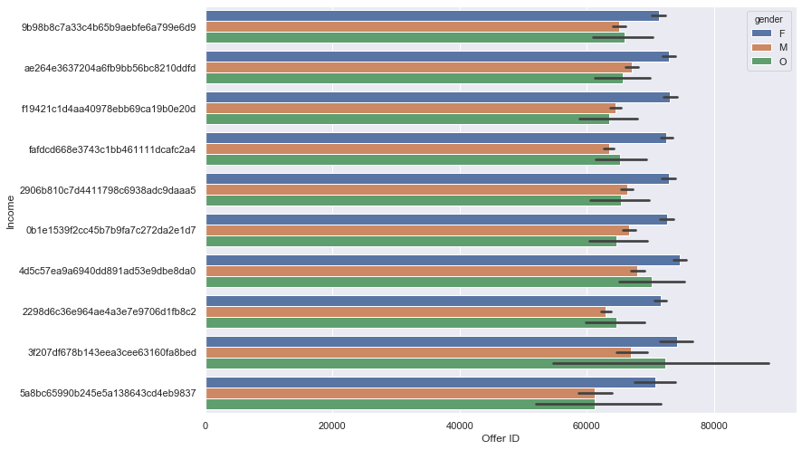

```python
sns.barplot(x = 'income', y = 'offer_id', hue = 'gender', data = successful)
plt.xlabel('Offer ID')
plt.ylabel('Income')
plt.show()
```

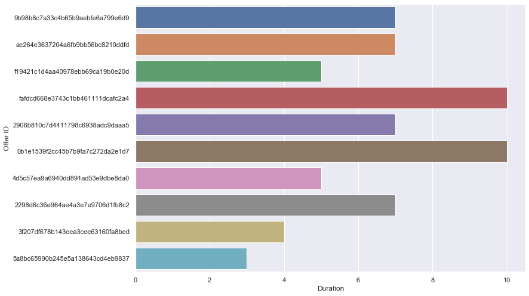

```python
sns.barplot(x = 'duration', y = 'offer_id', data = successful)
plt.xlabel('Duration')
plt.ylabel('Offer ID')
plt.show()
```

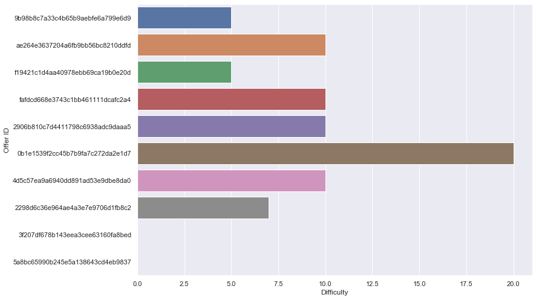

```python
sns.barplot(x = 'difficulty', y = 'offer_id', data = successful)
plt.xlabel('Difficulty')
plt.ylabel('Offer ID')
plt.show()
```

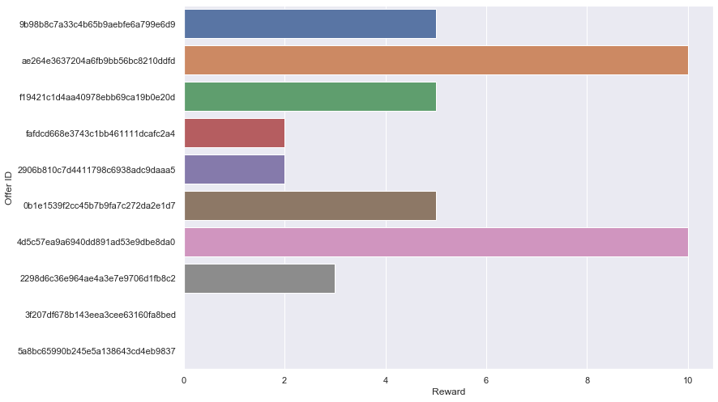

```python
sns.barplot(x = 'reward', y = 'offer_id', data = successful)
plt.xlabel('Reward')
plt.ylabel('Offer ID')
plt.show()
```

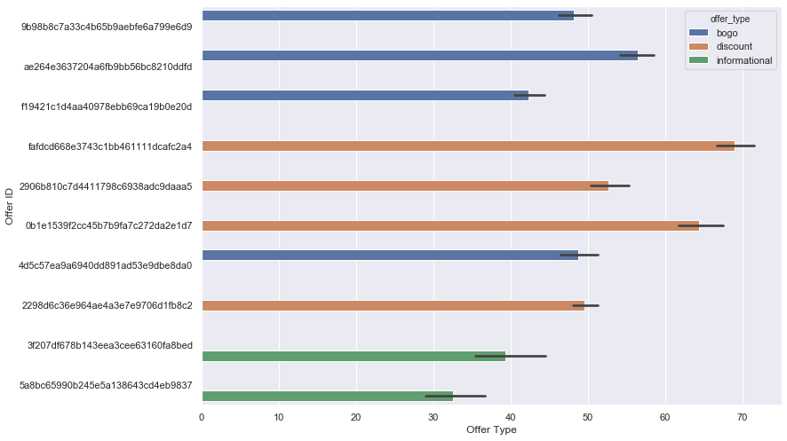

```python
sns.barplot(x = 'spent', y = 'offer_id',hue = 'offer_type', data = successful)
plt.xlabel('Offer Type')
plt.ylabel('Spent')
plt.show()
```

```python
combined_data.drop(columns= ['customer_id', 'became_member_on', 'offer_id', 'gender', 'offer_type'], inplace = True)
```

```python
combined_data
```

|  | success | time | spent | reward | difficulty | duration | web | email | mobile | social | bogo | discount | informational | age | income | start_year | start_month | male | female | other |
| --- | --- | --- | --- | --- | --- | --- | --- | --- | --- | --- | --- | --- | --- | --- | --- | --- | --- | --- | --- | --- |
| 0 | 1 | 0.0 | 37.67 | 5 | 5 | 7 | 1 | 1 | 1 | 0 | 1 | 0 | 0 | 75 | 100000.0 | 2017 | 5 | 0 | 1 | 0 |
| 1 | 0 | 7.0 | 49.39 | 0 | 0 | 3 | 0 | 1 | 1 | 1 | 0 | 0 | 1 | 75 | 100000.0 | 2017 | 5 | 0 | 1 | 0 |
| 2 | 1 | 17.0 | 48.28 | 10 | 10 | 7 | 0 | 1 | 1 | 1 | 1 | 0 | 0 | 75 | 100000.0 | 2017 | 5 | 0 | 1 | 0 |
| 3 | 1 | 21.0 | 48.28 | 5 | 5 | 5 | 1 | 1 | 1 | 1 | 1 | 0 | 0 | 75 | 100000.0 | 2017 | 5 | 0 | 1 | 0 |
| 4 | 0 | 0.0 | 0.00 | 2 | 10 | 7 | 1 | 1 | 1 | 0 | 0 | 1 | 0 | 68 | 70000.0 | 2018 | 4 | 1 | 0 | 0 |
| ... | ... | ... | ... | ... | ... | ... | ... | ... | ... | ... | ... | ... | ... | ... | ... | ... | ... | ... | ... | ... |
| 66496 | 0 | 24.0 | 34.04 | 2 | 10 | 7 | 1 | 1 | 1 | 0 | 0 | 1 | 0 | 59 | 44000.0 | 2017 | 8 | 1 | 0 | 0 |
| 66497 | 0 | 24.0 | 19.92 | 0 | 0 | 3 | 0 | 1 | 1 | 1 | 0 | 0 | 1 | 44 | 64000.0 | 2017 | 8 | 1 | 0 | 0 |
| 66498 | 0 | 24.0 | 28.42 | 5 | 5 | 7 | 1 | 1 | 1 | 0 | 1 | 0 | 0 | 61 | 73000.0 | 2018 | 4 | 1 | 0 | 0 |
| 66499 | 1 | 24.0 | 75.84 | 3 | 7 | 7 | 1 | 1 | 1 | 1 | 0 | 1 | 0 | 52 | 86000.0 | 2017 | 12 | 0 | 1 | 0 |
| 66500 | 1 | 24.0 | 14.25 | 3 | 7 | 7 | 1 | 1 | 1 | 1 | 0 | 1 | 0 | 20 | 70000.0 | 2016 | 10 | 1 | 0 | 0 |

66501 rows × 20 columns

```python
combined_data['success'].value_counts()
```

```
0    35136
1    31365
Name: success, dtype: int64
```

```python
#scale some features
from sklearn.preprocessing import MinMaxScaler
scaler = MinMaxScaler()

columns_to_scale = ['time', 'spent', 'reward', 'difficulty', 'duration', 'age', 'income']

combined_data[columns_to_scale] = scaler.fit_transform(combined_data[columns_to_scale])
```

```python
combined_data
```

|  | success | time | spent | reward | difficulty | duration | web | email | mobile | social | bogo | discount | informational | age | income | start_year | start_month | male | female | other |
| --- | --- | --- | --- | --- | --- | --- | --- | --- | --- | --- | --- | --- | --- | --- | --- | --- | --- | --- | --- | --- |
| 0 | 1 | 0.000000 | 0.031366 | 0.5 | 0.25 | 0.571429 | 1 | 1 | 1 | 0 | 1 | 0 | 0 | 0.686747 | 0.777778 | 2017 | 5 | 0 | 1 | 0 |
| 1 | 0 | 0.291667 | 0.041124 | 0.0 | 0.00 | 0.000000 | 0 | 1 | 1 | 1 | 0 | 0 | 1 | 0.686747 | 0.777778 | 2017 | 5 | 0 | 1 | 0 |
| 2 | 1 | 0.708333 | 0.040200 | 1.0 | 0.50 | 0.571429 | 0 | 1 | 1 | 1 | 1 | 0 | 0 | 0.686747 | 0.777778 | 2017 | 5 | 0 | 1 | 0 |
| 3 | 1 | 0.875000 | 0.040200 | 0.5 | 0.25 | 0.285714 | 1 | 1 | 1 | 1 | 1 | 0 | 0 | 0.686747 | 0.777778 | 2017 | 5 | 0 | 1 | 0 |
| 4 | 0 | 0.000000 | 0.000000 | 0.2 | 0.50 | 0.571429 | 1 | 1 | 1 | 0 | 0 | 1 | 0 | 0.602410 | 0.444444 | 2018 | 4 | 1 | 0 | 0 |
| ... | ... | ... | ... | ... | ... | ... | ... | ... | ... | ... | ... | ... | ... | ... | ... | ... | ... | ... | ... | ... |
| 66496 | 0 | 1.000000 | 0.028343 | 0.2 | 0.50 | 0.571429 | 1 | 1 | 1 | 0 | 0 | 1 | 0 | 0.493976 | 0.155556 | 2017 | 8 | 1 | 0 | 0 |
| 66497 | 0 | 1.000000 | 0.016586 | 0.0 | 0.00 | 0.000000 | 0 | 1 | 1 | 1 | 0 | 0 | 1 | 0.313253 | 0.377778 | 2017 | 8 | 1 | 0 | 0 |
| 66498 | 0 | 1.000000 | 0.023664 | 0.5 | 0.25 | 0.571429 | 1 | 1 | 1 | 0 | 1 | 0 | 0 | 0.518072 | 0.477778 | 2018 | 4 | 1 | 0 | 0 |
| 66499 | 1 | 1.000000 | 0.063148 | 0.3 | 0.35 | 0.571429 | 1 | 1 | 1 | 1 | 0 | 1 | 0 | 0.409639 | 0.622222 | 2017 | 12 | 0 | 1 | 0 |
| 66500 | 1 | 1.000000 | 0.011865 | 0.3 | 0.35 | 0.571429 | 1 | 1 | 1 | 1 | 0 | 1 | 0 | 0.024096 | 0.444444 | 2016 | 10 | 1 | 0 | 0 |

66501 rows × 20 columns

```python
#seperate the data into features and labels
features = combined_data.iloc[:, 1:]

labels = combined_data.iloc[:, 0]

#shuffle the data
from sklearn.utils import shuffle
features, labels = shuffle(features, labels)
```

```python
features
```

|  | time | spent | reward | difficulty | duration | web | email | mobile | social | bogo | discount | informational | age | income | start_year | start_month | male | female | other |
| --- | --- | --- | --- | --- | --- | --- | --- | --- | --- | --- | --- | --- | --- | --- | --- | --- | --- | --- | --- |
| 19227 | 1.000000 | 0.051266 | 0.3 | 0.35 | 0.571429 | 1 | 1 | 1 | 1 | 0 | 1 | 0 | 0.506024 | 0.611111 | 2016 | 8 | 1 | 0 | 0 |
| 35646 | 0.291667 | 0.034247 | 0.5 | 1.00 | 1.000000 | 1 | 1 | 0 | 0 | 0 | 1 | 0 | 0.445783 | 0.644444 | 2018 | 6 | 0 | 1 | 0 |
| 54874 | 1.000000 | 0.030225 | 0.0 | 0.00 | 0.142857 | 1 | 1 | 1 | 0 | 0 | 0 | 1 | 0.036145 | 0.011111 | 2017 | 5 | 1 | 0 | 0 |
| 47027 | 0.875000 | 0.051075 | 0.2 | 0.50 | 0.571429 | 1 | 1 | 1 | 0 | 0 | 1 | 0 | 0.481928 | 0.411111 | 2016 | 12 | 0 | 1 | 0 |
| 20168 | 1.000000 | 0.018510 | 1.0 | 0.50 | 0.571429 | 0 | 1 | 1 | 1 | 1 | 0 | 0 | 0.554217 | 0.611111 | 2015 | 9 | 0 | 1 | 0 |
| ... | ... | ... | ... | ... | ... | ... | ... | ... | ... | ... | ... | ... | ... | ... | ... | ... | ... | ... | ... |
| 6832 | 0.875000 | 0.003431 | 0.2 | 0.50 | 1.000000 | 1 | 1 | 1 | 1 | 0 | 1 | 0 | 0.108434 | 0.388889 | 2017 | 8 | 1 | 0 | 0 |
| 29708 | 0.291667 | 0.000000 | 0.0 | 0.00 | 0.000000 | 0 | 1 | 1 | 1 | 0 | 0 | 1 | 0.108434 | 0.433333 | 2017 | 10 | 1 | 0 | 0 |
| 21800 | 0.000000 | 0.003639 | 0.5 | 0.25 | 0.285714 | 1 | 1 | 1 | 1 | 1 | 0 | 0 | 0.325301 | 0.266667 | 2014 | 5 | 1 | 0 | 0 |
| 48611 | 0.708333 | 0.003497 | 0.3 | 0.35 | 0.571429 | 1 | 1 | 1 | 1 | 0 | 1 | 0 | 0.650602 | 0.277778 | 2017 | 12 | 0 | 1 | 0 |
| 12597 | 0.000000 | 0.071300 | 1.0 | 0.50 | 0.571429 | 0 | 1 | 1 | 1 | 1 | 0 | 0 | 0.409639 | 0.922222 | 2016 | 5 | 0 | 1 | 0 |

66501 rows × 19 columns

```python
labels.value_counts()
```

```
0    35136
1    31365
Name: success, dtype: int64
```

## Modeling

```python
#split the data into train and test sets
from sklearn.model_selection import train_test_split
X_train, X_test, y_train, y_test = train_test_split(features,labels,
                                                    test_size=0.20,
                                                    random_state=42)
```

```python
from sklearn.metrics import accuracy_score
from sklearn.metrics import precision_score,recall_score
def evaluate_model (predictor, X_test, y_test):
    """
    function to evaluate the models
    INPUT:
        predictor: the model object or endpoint.
        X_test, y_test: The test set.
    """
    y_pred = predictor.predict(X_test)

    print('Accuracy: ' , accuracy_score(y_test, y_pred))
    print('Precision: ',precision_score(y_test, y_pred))
    print('Recall: ',recall_score(y_test, y_pred))
```

## Benchmaek Model

#### Logistic Regression

```python
from sklearn.linear_model import LogisticRegression

#train the logistic regression model
lr = LogisticRegression()
lr.fit(X_train, y_train)

#evaluate the model
print("Logistic Regression Model: ")
evaluate_model(lr, X_test, y_test)
```

```
Logistic Regression Model:
Accuracy:  0.6970904443274941
Precision:  0.6657324089098687
Recall:  0.7190885914595284
```

#### Random Forest Model

```python
from sklearn.ensemble import RandomForestClassifier

#train the random forest model
rf = RandomForestClassifier(max_depth=10)
rf.fit(X_train, y_train)

#evaluate the model
print("Random Forest Model: ")
evaluate_model(rf, X_test, y_test)
```

```
Random Forest Model:
Accuracy:  0.9177505450717991
Precision:  0.8954517704517705
Recall:  0.9348311026131294
```

## SageMaker Models

```python
#import sagemaker for training sagemaker models
import boto3
import sagemaker

sagemaker_session = sagemaker.Session()
role = sagemaker.get_execution_role()
```

```python
#split training data into train and validation data for xgboost model
X_train_xgb, X_val_xgb, y_train_xgb, y_val_xgb = train_test_split(X_train,y_train,
                                                    test_size=0.33,
                                                    random_state=42)
```

```python
#check the dir exists
data_dir = 'data/xgb'
if not os.path.exists(data_dir):
        os.makedirs(data_dir)
```

```python
#make csv files for train, validation and test
X_test.to_csv(os.path.join(data_dir, 'test.csv'), header=False, index=False)
pd.concat([y_val_xgb, X_val_xgb], axis=1).to_csv(os.path.join(data_dir, 'validation.csv'), header=False, index=False)
pd.concat([y_train, X_train], axis=1).to_csv(os.path.join(data_dir, 'train.csv'), header=False, index=False)
```

#### XGBoost Model

```python
#location to save data in s3
prefix = 'capstone-xgboost'

#upload data to s3
test_location = sagemaker_session.upload_data(os.path.join(data_dir, 'test.csv'), key_prefix=prefix)
val_location = sagemaker_session.upload_data(os.path.join(data_dir, 'validation.csv'), key_prefix=prefix)
train_location = sagemaker_session.upload_data(os.path.join(data_dir, 'train.csv'), key_prefix=prefix)
```

```python
from sagemaker.amazon.amazon_estimator import get_image_uri
container = get_image_uri(sagemaker_session.boto_region_name, 'xgboost','0.90-1')

#create xgb estimator
xgb = sagemaker.estimator.Estimator(container,
                                   role,
                                   train_instance_count = 1,
                                   train_instance_type = 'ml.m4.xlarge',
                                   output_path = 's3://{}/{}/output'.format(sagemaker_session.default_bucket(), prefix),
                                   sagemaker_session = sagemaker_session)

#set the hyperparameters
xgb.set_hyperparameters(max_depth = 2,
                       eta = 0.02,
                       gamma = 3.60,
                       min_child_weight = 2,
                       subsample = 0.70,
                       objective = 'binary:logistic',
                       early_stopping_rounds = 100,
                       num_round = 400)
```

```
'get_image_uri' method will be deprecated in favor of 'ImageURIProvider' class in SageMaker Python SDK v2.
There is a more up to date SageMaker XGBoost image. To use the newer image, please set 'repo_version'='1.0-1'. For example:
	get_image_uri(region, 'xgboost', '1.0-1').
Parameter image_name will be renamed to image_uri in SageMaker Python SDK v2.
```

```python
from sagemaker.tuner import IntegerParameter, ContinuousParameter, HyperparameterTuner


#make hyperparameter tuner to tune the model with hyperparamters ranges,
#we'll train 6 different models and our goal is to maximize accuracy.
xgb_tuner = HyperparameterTuner(estimator = xgb,
                               objective_metric_name = 'validation:auc',
                               objective_type = 'Maximize',
                               max_jobs = 6,
                               max_parallel_jobs = 3,
                               hyperparameter_ranges = {
                                   'max_depth': IntegerParameter(2, 4),
                                   'eta': ContinuousParameter(0.02, 0.04),
                                   'gamma': ContinuousParameter(3.60, 3.65),
                                   'min_child_weight': IntegerParameter(1, 2),
                                   'num_round': IntegerParameter(400, 700),
                                   'subsample': ContinuousParameter(0.70, 0.73),
                               })
```

```python
#get the location of the data in s3
s3_input_train = sagemaker.s3_input(s3_data=train_location, content_type='csv')
s3_input_validation = sagemaker.s3_input(s3_data=val_location, content_type='csv')

#train the models
xgb_tuner.fit({'train': s3_input_train, 'validation': s3_input_validation})
```

```
's3_input' class will be renamed to 'TrainingInput' in SageMaker Python SDK v2.
's3_input' class will be renamed to 'TrainingInput' in SageMaker Python SDK v2.
```

```python
#wait for the tuner to finish
xgb_tuner.wait()
```

```
...........................................................................................!
```

```python
#find the best model
xgb_best = sagemaker.estimator.Estimator.attach(xgb_tuner.best_training_job())
```

```
Parameter image_name will be renamed to image_uri in SageMaker Python SDK v2.
```

[output not shown]

[output cut: 667 more lines]

[output not shown]

```python
#make batch transformer to test the model
xgb_transformer = xgb_best.transformer(instance_count = 1, instance_type = 'ml.m4.xlarge')
xgb_transformer.transform(test_location, content_type='text/csv', split_type='Line')
```

```
Parameter image will be renamed to image_uri in SageMaker Python SDK v2.
```

```python
#wait the transformer to finish
xgb_transformer.wait()
```

[output not shown]

```python
#move the output of the transformer from s3 to data_dir
!aws s3 cp --recursive $xgb_transformer.output_path $data_dir
```

```
download: s3://sagemaker-us-east-2-752518201364/sagemaker-xgboost-200821-0033-005-0d228-2020-08-21-00-41-45-143/test.csv.out to data/xgb/test.csv.out
```

```python
#evaluate the model
predictions = pd.read_csv(os.path.join(data_dir, 'test.csv.out'), header=None)
predictions = [round(num) for num in predictions.squeeze().values]
```

```python
print( 'Accuracy: ' , accuracy_score(y_test, predictions))
print('Precision Metric:',precision_score(y_test, predictions))
print('Recall Metric:',recall_score(y_test, predictions))
```

```
Accuracy:  0.9182768212916322
Precision Metric: 0.9019820377825952
Recall Metric: 0.9276954929128842
```

#### LinearLearner Model

```python
#make LinearLearner model
from sagemaker import LinearLearner
prefix = 'linear'
linear = LinearLearner(role = role,
                      train_instance_count = 1,
                      train_instance_type = 'ml.m4.xlarge',
                      predictor_type = 'binary_classifier',
                      output_path = 's3://{}/{}/output'.format(sagemaker_session.default_bucket(), prefix),
                      sagemaker_session = sagemaker_session,
                      epochs = 50)
```

```python
#change the values of the data to numpy array, then create a record set to train the model
train_x_np = X_train.values.astype('float32')
train_y_np = y_train.values.astype('float32')
formatted_train_data = linear.record_set(train_x_np, labels = train_y_np)
```

```python
#train the model
linear.fit(formatted_train_data)
```

```
'get_image_uri' method will be deprecated in favor of 'ImageURIProvider' class in SageMaker Python SDK v2.
's3_input' class will be renamed to 'TrainingInput' in SageMaker Python SDK v2.
'get_image_uri' method will be deprecated in favor of 'ImageURIProvider' class in SageMaker Python SDK v2.
```

[output not shown]

[output cut: 670 more lines]

[output not shown]

```python
#deploy the model
linear_predictor = linear.deploy(initial_instance_count = 1, instance_type = 'ml.t2.medium')
```

```
Parameter image will be renamed to image_uri in SageMaker Python SDK v2.
```

```
---------------!
```

```python
def evaluate(predictor, test_features, test_labels, verbose=True):
    """
    Evaluate a model on a test set given the prediction endpoint.
    Return binary classification metrics.
    :param predictor: A prediction endpoint
    :param test_features: Test features
    :param test_labels: Class labels for test data
    :param verbose: If True, prints a table of all performance metrics
    :return: A dictionary of performance metrics.
    """

    # We have a lot of test data, so we'll split it into batches of 100
    # split the test data set into batches and evaluate using prediction endpoint
    prediction_batches = [predictor.predict(batch) for batch in np.array_split(test_features, 100)]

    # LinearLearner produces a `predicted_label` for each data point in a batch
    # get the 'predicted_label' for every point in a batch
    test_preds = np.concatenate([np.array([x.label['predicted_label'].float32_tensor.values[0] for x in batch])
                                 for batch in prediction_batches])

    # calculate true positives, false positives, true negatives, false negatives
    tp = np.logical_and(test_labels, test_preds).sum()
    fp = np.logical_and(1-test_labels, test_preds).sum()
    tn = np.logical_and(1-test_labels, 1-test_preds).sum()
    fn = np.logical_and(test_labels, 1-test_preds).sum()

    # calculate binary classification metrics
    recall = tp / (tp + fn)
    precision = tp / (tp + fp)
    accuracy = (tp + tn) / (tp + fp + tn + fn)

    # printing a table of metrics
    if verbose:
        print(pd.crosstab(test_labels, test_preds, rownames=['actual (row)'], colnames=['prediction (col)']))
        print("\n{:<11} {:.3f}".format('Recall:', recall))
        print("{:<11} {:.3f}".format('Precision:', precision))
        print("{:<11} {:.3f}".format('Accuracy:', accuracy))
        print()

    return {'TP': tp, 'FP': fp, 'FN': fn, 'TN': tn,
            'Precision': precision, 'Recall': recall, 'Accuracy': accuracy}
```

```python
metrics = evaluate(linear_predictor,
                   X_test.values.astype('float32'),
                   y_test.values,
                   verbose=True) # verbose means we'll print out the metrics
```

```
prediction (col)   0.0   1.0
actual (row)
0                 6226   796
1                  679  5600

Recall:     0.892
Precision:  0.876
Accuracy:   0.889
```

```python
def delete_endpoint(predictor):
        try:
            boto3.client('sagemaker').delete_endpoint(EndpointName=predictor.endpoint)
            print('Deleted {}'.format(predictor.endpoint))
        except:
            print('Already deleted: {}'.format(predictor.endpoint))
```

```python
delete_endpoint(linear_predictor)
```

```
Deleted linear-learner-2020-08-21-00-15-57-800
```

# Conclusion

- Random Forest Classifier: 91.7%
- XGBoost: 91.8%
- LinearLearner: 88.9%
- Logistic Regression: 69.7%

### The obtained results is good.

### Future Work

- Collect more data.
- Collect data about more than one product.
- Train a deep learning model.